# LCLD-业务分析-属性含义分析-问题探索-缺失值处理-数值转换

## Step 1：业务了解

**1. 这家公司是干嘛的？**

这家公司就是P2P网贷平台的鼻祖。主要的服务对象和国内的当天贷不同，但和优选宝类似。

- 在Lending Club（LC）上个人既可以贷款又可以投资，而当天贷则不能申请贷款，优选宝和LC的服务对象类似。
- LC的贷款模式是：贷款者提出贷款申请并由LC进行筛选，之后LC会将通过筛选的贷款信息发布到官网，并由投资者进行投资（每笔贷款可由多个人投资，一个人可投资多笔贷款），每一笔贷款投满之后贷款者将收到借款，而投资者则可以获得利息。下图为投资者界面。

[figure not shown]

- LC贷款模式参考：http://01caijing.baijia.baidu.com/article/440149
- LC官网使用更改host方式访问非常缓慢，建议使用VPN访问。

**2. 这些数据是基于什么业务？数据集中的属性含义？属性之间的关系如何？**

数据基于私人贷款、商业贷款以及投资业务，其中私人贷款和商业贷款都分有多种贷款类型，每种贷款类型可贷额度不同。 贷款者信用评分对贷款利率有很强的影响。信用评分本身主要受以下因素影响：

- 付款历史记录：主要查看是否有推迟付款或拒绝付款（赖账）的行为。
- 信用总额：信用报告中所列的所有信用账户的总额。
- 信用历史：开通信用的时间。
- 新的信用：最近开通的新信用的信息。
- credit mix：多种信用类型的开通记录。

**注：FICO Credit Score计算方式参考：www.myfico.com/Downloads/Files/myFICO_UYFS_Booklet.pdf。虽然FICO提供了影响Credit Score的因素，但对于评估Credit Score所使用的具体算法并没有公开。**

**3. 背景知识**

- 信用报告：信用报告由专门的信用局维护，个人可以申请修改。
- 信用评分：FICO信用评分为美国使用最为广泛的信用评分，评分所需的信息主要是从信用报告中提取。
- 信用额度：可在提供信用额度的平台上开通。Lending Club也提供这项服务。

## step 2：读取数据

```python
import pandas as pd

lcDataDictionary = pd.read_excel('./lending-club-loan-data/lending-club-loan-data/LCDataDictionary.xlsx', 'LoanStats')
loan_data = pd.read_csv('./lending-club-loan-data/lending-club-loan-data/loan.csv', header=0)
```

```
/home/hcq/software/anaconda2/lib/python2.7/site-packages/IPython/core/interactiveshell.py:2723: DtypeWarning: Columns (19,55) have mixed types. Specify dtype option on import or set low_memory=False.
  interactivity=interactivity, compiler=compiler, result=result)
```

**在读取借款数据时，python发出警告，参考以下文章：**

**http://stackoverflow.com/questions/24251219/pandas-read-csv-low-memory-and-dtype-options**

**通过阅读文章之后，发现警告出现的原因是：**

- python在从外部数据源中读取数据的过程中需要为属性值设定类型，这需要分析属性的所有值以确定一个最合适的类型。
- 如果数据集较大，确定属性值的类型将很耗内存，所以会发出 *low_memory* 的警告。
- 用户可以通过指定属性的类型以减少这种内存开销，但可能由于指定的类型不是最佳存储类型而引起更大的数据存储开销。

```python
print type(lcDataDictionary)
print type(loan_data)
```

```
<class 'pandas.core.frame.DataFrame'>
<class 'pandas.core.frame.DataFrame'>
```

**在python中，可以直接通过索引获取dataframe的某一列**

```python
loan_data[[19, 55]].head(3)
```

|  | desc | verification_status_joint |
| --- | --- | --- |
| 0 | Borrower added on 12/22/11 > I need to upgra... | NaN |
| 1 | Borrower added on 12/22/11 > I plan to use t... | NaN |
| 2 | NaN | NaN |

## Step 3: 属性值含义解释

```python
loan_data.info()
```

```
<class 'pandas.core.frame.DataFrame'>
RangeIndex: 887379 entries, 0 to 887378
Data columns (total 74 columns):
id                             887379 non-null int64
member_id                      887379 non-null int64
loan_amnt                      887379 non-null float64
funded_amnt                    887379 non-null float64
funded_amnt_inv                887379 non-null float64
term                           887379 non-null object
int_rate                       887379 non-null float64
installment                    887379 non-null float64
grade                          887379 non-null object
sub_grade                      887379 non-null object
emp_title                      835922 non-null object
emp_length                     887379 non-null object
home_ownership                 887379 non-null object
annual_inc                     887375 non-null float64
verification_status            887379 non-null object
issue_d                        887379 non-null object
loan_status                    887379 non-null object
pymnt_plan                     887379 non-null object
url                            887379 non-null object
desc                           126029 non-null object
purpose                        887379 non-null object
title                          887228 non-null object
zip_code                       887379 non-null object
addr_state                     887379 non-null object
dti                            887379 non-null float64
delinq_2yrs                    887350 non-null float64
earliest_cr_line               887350 non-null object
inq_last_6mths                 887350 non-null float64
mths_since_last_delinq         433067 non-null float64
mths_since_last_record         137053 non-null float64
open_acc                       887350 non-null float64
pub_rec                        887350 non-null float64
revol_bal                      887379 non-null float64
revol_util                     886877 non-null float64
total_acc                      887350 non-null float64
initial_list_status            887379 non-null object
out_prncp                      887379 non-null float64
```

[output cut: 24 more lines]

```
open_il_12m                    21372 non-null float64
open_il_24m                    21372 non-null float64
mths_since_rcnt_il             20810 non-null float64
total_bal_il                   21372 non-null float64
il_util                        18617 non-null float64
open_rv_12m                    21372 non-null float64
open_rv_24m                    21372 non-null float64
max_bal_bc                     21372 non-null float64
all_util                       21372 non-null float64
total_rev_hi_lim               817103 non-null float64
inq_fi                         21372 non-null float64
total_cu_tl                    21372 non-null float64
inq_last_12m                   21372 non-null float64
dtypes: float64(49), int64(2), object(23)
memory usage: 501.0+ MB
```

**结果显示，有74个属性。数据字典虽然提供了属性值的解释，但终究还是很难理解，我需要去查看官网，以进一步理解属性含义。**

id: 贷款信息编号

member_id: 贷款者编号

loan_amnt: 贷款金额

funded_amnt: 该笔贷款已投资额度---funded_amnt_inv: 该笔贷款已投资额度

- **以上两个属性有什么区别？**

term: 贷款的还款周期（单位：月）

int_rate: 贷款年利率

installment: 月还款金额

grade: 贷款产品等级（取值范围：A～G）

sub_grade: 贷款产品等级细分（每个等级下分为若干个子等级。eg：A1～A5）

emp_title: 贷款者工作单位

emp_length: 贷款者工作年限（0~10，超过10年以10年计）

home_ownership: 贷款者住房状态（租、已经拥有、抵押贷款、其他）

annual_inc: 贷款者年收入

verification_status: 贷款者收入情况的验证状态（取值范围：已验证/未验证）

issue_d: 贷款发放年月

loan_status: 贷款状态

pymnt_plan: 贷款产品有无还款计划

url: 贷款信息页面

desc: 贷款者贷款原因描述

purpose: 贷款者的贷款需求原因

title: 贷款用途

zip_code: 贷款者所在地区的邮政编码

addr_state: 贷款者所在的州简称

dti: 贷款者月债务总额除以月收入

delinq_2yrs: 贷款者过去两年逾期30天以上未还款的行为次数

earliest_cr_line: 贷款者信用额度第一次开通的年月

inq_last_6mths: 过去6个月贷款申请次数（汽车和抵押贷款除外）

mths_since_last_delinq: 贷款者最后一次不法行为到现在的时间（单位：月）

mths_since_last_record: 贷款者最后一次**公众记录**到现在的时间（单位：月）

open_acc: 贷款者信用文件当中的信用额度开通数量

pub_rec: 不良公众记录数量

revol_bal: 贷款者信贷周转总额

revol_util: 信贷周转金额利用比率

total_acc: 贷款者信用文件中当前的信用总额

initial_list_status: 贷款信息表初始状态（每一笔贷款都由一个listing，记录了贷款的详细信息）

out_prncp: 贷款（指的是投资者投资的总额，并不是贷款者申请额度，因为一笔贷款可能只能借到90%）剩余的未偿还本金

out_prncp_inv: 部分投资者剩余的未偿还本金？

total_pymnt: 贷款迄今为止收到的还款总额

total_pymnt_inv: 贷款迄今为止部分投资者所收到的还款？

total_rec_prncp: 贷款迄今为止所收到的本金

total_rec_int: 贷款迄今为止所收到的利润

total_rec_late_fee: 贷款迄今为止所收到的逾期赔偿（逾期还要赔偿！！！）

recoveries: 注销总回收率？

collection_recovery_fee: 贷款注销费用？

last_pymnt_d: 最近一次收到还款的上一个月份

last_pymnt_amnt: 最近一次收到的还款总额

next_pymnt_d: 下一次应还款日期

last_credit_pull_d: LC为此次贷款减少信贷的最近月份？

collections_12_mths_ex_med: 12个月中讨债事件的数量，排除医学讨债事件

mths_since_last_major_derog: 最近90天差评的月份？

policy_code: 贷款信息代码（公众可参与为1，新产品公众不可参与为2）

application_type: 指示一笔贷款为个人申请还是多人申请的标识

annual_inc_joint: 贷款者团队其他成员自报的年收入

dti_joint: 贷款者团队其他成员月债务总额除以月收入

verification_status_joint: 贷款者团队其他成员收入情况的验证状态

acc_now_delinq: 贷款者违约账目的数量

tot_coll_amt: 总讨债事件次数

tot_cur_bal: 所有账户的总余额（所有账户是指开通的所有信用账户）

open_acc_6m: 最近6个月的开通交易的次数

open_il_6m: 当前**活跃的**分期付款交易次数？

open_il_12m: 过去12个月分期付款账户的开通数量

open_il_24m: 过去24个月分期付款账户的开通数量

mths_since_rcnt_il: 分期付款账户最近一次开通的时间到现在的月数

total_bal_il: 所有分期付款账户的总余额

il_util: 在当前分期付款账户当中，高信用余额比率？

open_rv_12m: 过去12个月周转交易开通的数量？

open_rv_24m: 过去24个月周转交易开通的数量？

max_bal_bc: 所有周转账户当中最大的账户余额

all_util: 贸易信贷余额？

total_rev_hi_lim: 总周转信贷限额？

inq_fi: 私人融资咨询次数

total_cu_tl: 融资交易次数

inq_last_12m: 过去12个月信用咨询次数

*这真的是一张大表啊。。。都有点糊涂了！！！*

**了解完这些属性之后，有几点不明白：**

- 这张表是关于一个信贷产品的么？
- 贷款产品的投资者是什么意思？参考funded_amnt_inv属性含义。
- 一次贷款的责任人可以是多个人？参考annual_inc_joint属性含义。
- 美国的公众记录是什么意思？参考mths_since_last_record属性含义

**经过这次的属性含义探究，方才发现业务知识的重要性。如果你不懂业务，属性含义你都搞不清，你还做何分析？？？**

**经过查看官网，上面一些问题有了答案。**

- 这张表中的每行数据都是关于一次贷款的信息。
- 在LC中可以开设联合账户，由多个人共同管理。因此，一笔贷款可能有多个责任人；同理，一笔投资也可能有多个责任人。

### 注：这张属性含义表经过两次修改，有些属性还是不能明白其含义，先放一放把。

## Step 4：问题探索

**纵观数据集中的74个属性，我们可以发现这批数据主要包含三方面的信息：**

- 贷款用户基本信息（包括住房状态、工作年限、工作单位、年收入等信息）
- 贷款用户的信用信息（包括信用账户、不良记录等信息）
- 该笔贷款信息（包括贷款用途、还款状态、还款周期等信息）

**那么，从这批数据当中我们能得到什么信息呢？对于不同的人群，他们想获得的信息都不同，以下是我的思考逻辑：**

**1. 最想从这批数据中获益的莫过于发布者本人了，那么LC希望从这批数据中挖掘什么信息呢？**

- 我应该给一个贷款用户贷多少款？还款周期多长？
- 对于一个投资者，当他想手动投资时，我希望能够给他推荐一个投资组合
- 投资用户倾向于投资哪些类型的贷款？
- 我们的贷款风险等级是否合理？
- 哪种贷款投资回报率最高？（参考自： https://www.kaggle.com/rgalbo/d/wendykan/lending-club-loan-data/notebook-119d5a92add5a1090032/discussion ）
- 其他？

**2. 站在竞争者的角度思考，他能从这批数据中得到什么信息？**

- LC公司的贷款走势如何？年增长率怎样？
- LC公司的贷款人群信息？
- 其他？

**3. 合作者（包括银行和投行）能从这些数据中得到什么信息？**

- 合作者貌似没必要从这批数据中获取信息，他们应该能够得到更直接、更全面的信息。
- 其他？

**4. 如果用户也会使用大数据工具，那么我想知道的会是什么？**

- 作为个人投资者，我会思考LC的违约率如何？哪些贷款违约率最高？
- 作为投资者，我会思考如何使我的投资组合利益最大化的同时风险能够在我的承受范围内。
- 作为贷款者，你想知道什么？
- 其他？

## Step 5：统计分析

在解决以上提出的问题之前，我想咱们应该先进行一些基本的统计分析，以熟悉python的pandas库。

### 1. 属性分类

在step4中，我们发现这批数据主要包含三方面的信息，因此，我们可以将属性分门别类的划分为3大类。（**注：在此，或许有人会问为什么要分类了。我的思考是属性太多容易引起思维混乱，分门别类的归纳更容易理清思路。**）

| 贷款用户基本信息 | 贷款用户的信用信息 | 贷款信息 |
| --- | --- | --- |
| member_id | delinq_2yrs | id、loan_amnt |
| emp_title | earliest_cr_line、inq_last_6mths | funded_amnt、funded_amnt_inv |
| emp_length | mths_since_last_delinq、mths_since_last_record | term、grade、sub_grade |
| home_ownership | open_acc、 pub_rec、revol_bal | installment、int_rate |
| annual_inc | revol_util、total_acc | issue_d 、loan_status |
| verification_status | recoveries、collections_12_mths_ex_med | pymnt_plan、url、 |
| zip_code | mths_since_last_major_derog | desc、purpose、title |
| dti | acc_now_delinq、tot_coll_amt | initial_list_status、out_prncp |
| annual_inc_joint | tot_cur_bal、open_acc_6m | out_prncp_inv、total_pymnt、total_pymnt_inv |
| addr_state | open_il_6m、 open_il_12m | total_rec_prncp、total_rec_int |
| dti_joint | open_il_24m、mths_since_rcnt_il | total_rec_late_fee、collection_recovery_fee |
| verification_status_joint | total_bal_il、il_util | last_pymnt_d、last_pymnt_amnt |
|  | open_rv_12m、open_rv_24m | next_pymnt_d、last_credit_pull_d |
|  | max_bal_bc、all_util | policy_code、application_type |
|  | total_rev_hi_lim、inq_fi |  |
|  | total_cu_tl、inq_last_12m |  |

### 2. 数据预处理

### 2.1 数据清洗

#### 2.1.1 缺失值处理

运行以下命令查看缺失值数量。

```python
null_data = loan_data.isnull().sum(0)
```

```python
null_data = null_data[null_data > 0]
```

```python
null_data.sort_values()
```

```
annual_inc                          4
acc_now_delinq                     29
delinq_2yrs                        29
earliest_cr_line                   29
inq_last_6mths                     29
open_acc                           29
pub_rec                            29
total_acc                          29
last_credit_pull_d                 53
collections_12_mths_ex_med        145
title                             151
revol_util                        502
last_pymnt_d                    17659
emp_title                       51457
total_rev_hi_lim                70276
tot_coll_amt                    70276
tot_cur_bal                     70276
next_pymnt_d                   252971
mths_since_last_delinq         454312
mths_since_last_major_derog    665676
mths_since_last_record         750326
desc                           761350
inq_fi                         866007
all_util                       866007
max_bal_bc                     866007
open_rv_24m                    866007
open_rv_12m                    866007
total_bal_il                   866007
inq_last_12m                   866007
open_il_24m                    866007
open_il_12m                    866007
open_il_6m                     866007
open_acc_6m                    866007
total_cu_tl                    866007
mths_since_rcnt_il             866569
il_util                        868762
verification_status_joint      886868
annual_inc_joint               886868
dti_joint                      886870
dtype: int64
```

对于缺失值过多的直接将其删除。

```python
null_data = null_data.drop(null_data.index[null_data > 250000])
null_data
```

```
emp_title                     51457
annual_inc                        4
title                           151
delinq_2yrs                      29
earliest_cr_line                 29
inq_last_6mths                   29
open_acc                         29
pub_rec                          29
revol_util                      502
total_acc                        29
last_pymnt_d                  17659
last_credit_pull_d               53
collections_12_mths_ex_med      145
acc_now_delinq                   29
tot_coll_amt                  70276
tot_cur_bal                   70276
total_rev_hi_lim              70276
dtype: int64
```

接下来再探究缺失值的相关性。

```python
# 取出包含缺失值的所有列
null_data_cor = loan_data.isnull()
null_data_cor = null_data_cor[null_data.index]
def map_data(x):
    if x == True:
        return 1
    else:
        return 0
null_data_cor = null_data_cor.applymap( map_data )
```

```python
null_data_cor = null_data_cor.corr().abs()
def map_data_equal_1(x):
    if x == 1:
        return 0;
    else:
        return x;
null_data_cor = null_data_cor.applymap( map_data_equal_1 )
# 提取相关性大于0.5的属性
null_data_cor = null_data_cor[null_data_cor > 0.5]
null_data_cor
```

|  | emp_title | annual_inc | title | delinq_2yrs | earliest_cr_line | inq_last_6mths | open_acc | pub_rec | revol_util | total_acc | last_pymnt_d | last_credit_pull_d | collections_12_mths_ex_med | acc_now_delinq | tot_coll_amt | tot_cur_bal | total_rev_hi_lim |
| --- | --- | --- | --- | --- | --- | --- | --- | --- | --- | --- | --- | --- | --- | --- | --- | --- | --- |
| emp_title | NaN | NaN | NaN | NaN | NaN | NaN | NaN | NaN | NaN | NaN | NaN | NaN | NaN | NaN | NaN | NaN | NaN |
| annual_inc | NaN | NaN | NaN | NaN | NaN | NaN | NaN | NaN | NaN | NaN | NaN | NaN | NaN | NaN | NaN | NaN | NaN |
| title | NaN | NaN | NaN | NaN | NaN | NaN | NaN | NaN | NaN | NaN | NaN | NaN | NaN | NaN | NaN | NaN | NaN |
| delinq_2yrs | NaN | NaN | NaN | NaN | NaN | NaN | NaN | NaN | NaN | NaN | NaN | NaN | NaN | NaN | NaN | NaN | NaN |
| earliest_cr_line | NaN | NaN | NaN | NaN | NaN | NaN | NaN | NaN | NaN | NaN | NaN | NaN | NaN | NaN | NaN | NaN | NaN |
| inq_last_6mths | NaN | NaN | NaN | NaN | NaN | NaN | NaN | NaN | NaN | NaN | NaN | NaN | NaN | NaN | NaN | NaN | NaN |
| open_acc | NaN | NaN | NaN | NaN | NaN | NaN | NaN | NaN | NaN | NaN | NaN | NaN | NaN | NaN | NaN | NaN | NaN |
| pub_rec | NaN | NaN | NaN | NaN | NaN | NaN | NaN | NaN | NaN | NaN | NaN | NaN | NaN | NaN | NaN | NaN | NaN |
| revol_util | NaN | NaN | NaN | NaN | NaN | NaN | NaN | NaN | NaN | NaN | NaN | NaN | NaN | NaN | NaN | NaN | NaN |
| total_acc | NaN | NaN | NaN | NaN | NaN | NaN | NaN | NaN | NaN | NaN | NaN | NaN | NaN | NaN | NaN | NaN | NaN |
| last_pymnt_d | NaN | NaN | NaN | NaN | NaN | NaN | NaN | NaN | NaN | NaN | NaN | NaN | NaN | NaN | NaN | NaN | NaN |
| last_credit_pull_d | NaN | NaN | NaN | NaN | NaN | NaN | NaN | NaN | NaN | NaN | NaN | NaN | NaN | NaN | NaN | NaN | NaN |
| collections_12_mths_ex_med | NaN | NaN | NaN | NaN | NaN | NaN | NaN | NaN | NaN | NaN | NaN | NaN | NaN | NaN | NaN | NaN | NaN |
| acc_now_delinq | NaN | NaN | NaN | NaN | NaN | NaN | NaN | NaN | NaN | NaN | NaN | NaN | NaN | NaN | NaN | NaN | NaN |
| tot_coll_amt | NaN | NaN | NaN | NaN | NaN | NaN | NaN | NaN | NaN | NaN | NaN | NaN | NaN | NaN | NaN | NaN | NaN |
| tot_cur_bal | NaN | NaN | NaN | NaN | NaN | NaN | NaN | NaN | NaN | NaN | NaN | NaN | NaN | NaN | NaN | NaN | NaN |
| total_rev_hi_lim | NaN | NaN | NaN | NaN | NaN | NaN | NaN | NaN | NaN | NaN | NaN | NaN | NaN | NaN | NaN | NaN | NaN |

**通过上表可以看出，没有任何两个属性的缺失相关性超过0.5。也就是说，一个属性缺失，另一个属性伴随缺失的可能性不大。**

接下来让我们来填补缺失值。

| 属性名 | 属性含义 | 缺失数量 | 填补方案 |
| --- | --- | --- | --- |
| emp_title | 贷款者工作单位 | 51457 | 该属性值为描述型，不好填补，暂时不处理 |
| annual_inc | 贷款者年收入 | 4 | 数值型属性，且缺失数量较少，可以使用**贷款的评级（sub_grade）**来估计 |
| title | 贷款用途 | 151 | 描述型属性，为贷款者所提供，不做处理 |
| delinq_2yrs | 贷款者过去两年逾期30天以上未还款的行为次数 | 29 | 数值型属性，缺失数量较少，可以使用**贷款的评级（sub_grade）**来估计 |
| earliest_cr_line | 贷款者信用额度第一次开通的年月 | 29 | 在美国，学生也可以开通信用卡，因此信用卡的最早开通时间应和年龄相关，但贷款数据集中并没有年龄属性。不过幸运的是，数据集中提供了**贷款者工作年限（emp_length）**这个属性 |
| inq_last_6mths | 过去6个月贷款申请次数（汽车和抵押贷款除外） | 29 | 年收入越高，相对来说贷款的申请次数就会越少。因此，可以利用**年收入（annual_inc）**估计该属性缺失值 |
| open_acc | 贷款者信用文件当中的信用额度开通数量 | 29 | 在美国，开通信用卡除了缓解财务上的紧张感之外，它也极大的方便了美国人民的生活，就算是年收入较高的人群也会办理较多信用卡。**但是在LC上贷款的人群，我想他们财务上的紧张感较强，这和他们的年收入有较大关系，所以使用年收入（annual_inc）估计该属性值** |
| pub_rec | 不良公众记录数量 | 29 | 根据FICO的调查发现，几乎没有人的信用报告上会有public record。但是从这些数据当中又发现，有些人的public record数量达到了80+，实在不可思议。**现在还未想到可行的填补方法。** |
| revol_util | 信贷周转金额利用比率 | 502 | 显然和**年收入（annual_inc）**有较大关联 |
| total_acc | 贷款者信用文件中当前的信用总额 | 29 | **工作年限（emp_length）**越长，开通的信用数量越多；**年收入（annual_inc）**越低，相对来说，开通的数量就越多 |
| last_pymnt_d | 最近一次收到还款的上一个月份 | 17659 | 这个值怎么会缺失？ |
| last_credit_pull_d | LC为此次贷款减少信贷的最近月份？ | 53 | **不明白什么意思！！！** |
| collections_12_mths_ex_med | 12个月中讨债事件的数量，排除医学讨债事件 | 145 | 发生讨债事件，如果事件真实，那么和你个人的**年收入（annual_inc）**应该是有很大关系的 |
| acc_now_delinq | 贷款者违约账目的数量 | 29 | 直观上和**信贷周转金额利用比率（revol_util）**以及**年收入（annual_inc）**相关 |
| tot_coll_amt | 总讨债事件次数 | 70276 | 和collections_12_mths_ex_med属性填补方式相同 |
| tot_cur_bal | 所有信用账户的总余额 | 70276 | revol_util = （total_acc - tot_cur_bal）/total_acc |
| total_rev_hi_lim | 总周转信贷限额？ | 70276 | **不明白什么意思！！！** |

**思考：通过绘制上表，脑中同时也在思考以下问题：**

- 哪些属性应该填补缺失值？哪些不需要？如何判断？
- 如何判断一个属性的缺失值应该由哪些属性值共同来填补？这应该需要对业务有相当的熟悉度。
- 根据业务知识来判断缺失值的处理方式是否就一定正确？还是需要用数据说话。

```python
import numpy as np
# 使用贷款的评级（sub_grade）来填补annual_inc
sub_grade_unique_value = loan_data.sub_grade.unique()  # sub_grade 的唯一值列表
mode_of_annual_inc_with_sub_grade = np.zeros(len(sub_grade_unique_value))  # 用来存储根据sub_grade分组得到的annual_inc的众数
for i in xrange(len(sub_grade_unique_value)):
    #print sub_grade_unique_value[i]  # 调试代码
    mode_of_annual_inc_with_sub_grade[i] = loan_data[loan_data.sub_grade == sub_grade_unique_value[i]]['annual_inc'].mode()
mode_of_annual_inc_with_sub_grade
```

```
array([ 60000.,  60000.,  60000.,  60000.,  60000.,  60000.,  60000.,
        60000.,  60000.,  60000.,  60000.,  60000.,  60000.,  60000.,
        60000.,  60000.,  60000.,  60000.,  60000.,  60000.,  60000.,
        60000.,  60000.,  60000.,  60000.,  60000.,  60000.,  60000.,
        65000.,  60000.,  50000.,  60000.,  60000.,  60000.,  60000.])
```

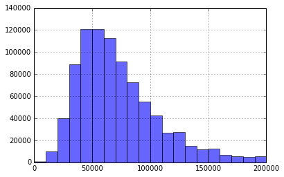

```python
# 有点不大敢相信上面的结果，因此绘制年收入分布图。
# 由于年收入大于20万的极少，就并未考虑大于20万的数据
import matplotlib.pyplot as plt
%matplotlib inline
%pylab inline
loan_data.annual_inc.hist(bins=20, range=(0, 200000), alpha=0.6)
```

**思考：通过以上结果可以发现，贷款者自报的年收入和贷款评级并没有很大的关系。这或许是因为LC并不相信贷款者自报的年收入。因此，在对贷款评级时年收入并没有占很大比重。**

接下来我们直接使用年收入的**众数**（不使用均值是因为年收入的极值非常大，对均值影响较大）来填补缺失值。

```python
# 直接使用众数填充缺失值
loan_data.annual_inc.replace(np.NaN, loan_data.annual_inc.mode(), inplace=True)
loan_data.annual_inc.isnull().sum()
```

```
4
```

```python
loan_data.loc[loan_data.annual_inc.isnull(), 'annual_inc'] = loan_data.annual_inc.dropna().mode().values[0]
loan_data.loc[loan_data.annual_inc.isnull(), 'annual_inc']
```

```
Series([], Name: annual_inc, dtype: float64)
```

**终于被我查出原因了：loan_data.annual_inc.mode()方法返回的是一个Series。不能将一个Series赋值给float类型。我们应该将Series的值取出赋给float类型的数据。**

```python
# delinq_2yrs：数值型属性，缺失数量较少，可以使用贷款的评级（sub_grade）来估计
sub_grade_unique_value = loan_data.sub_grade.unique()  # sub_grade 的唯一值列表
mode_of_delinq_2yrs_with_sub_grade = np.zeros(len(sub_grade_unique_value))  # 用来存储根据sub_grade分组得到的delinq_2yrs的众数
for i in xrange(len(sub_grade_unique_value)):
    mode_of_delinq_2yrs_with_sub_grade[i] = loan_data[loan_data.sub_grade == sub_grade_unique_value[i]]['delinq_2yrs'].mode()
mode_of_delinq_2yrs_with_sub_grade
```

```
array([ 0.,  0.,  0.,  0.,  0.,  0.,  0.,  0.,  0.,  0.,  0.,  0.,  0.,
        0.,  0.,  0.,  0.,  0.,  0.,  0.,  0.,  0.,  0.,  0.,  0.,  0.,
        0.,  0.,  0.,  0.,  0.,  0.,  0.,  0.,  0.])
```

```python
loan_data['delinq_2yrs_fill'] = loan_data['delinq_2yrs']
for i in xrange(len(sub_grade_unique_value)):
    loan_data.loc[ (loan_data.delinq_2yrs_fill.isnull()) & (loan_data.sub_grade == sub_grade_unique_value[i]), 'delinq_2yrs_fill' ] = \
        mode_of_delinq_2yrs_with_sub_grade[i]
```

```python
# earliest_cr_line	贷款者信用额度第一次开通的年月
# 在美国，学生也可以开通信用卡，因此信用卡的最早开通时间应和年龄相关，但贷款数据集中并没有年龄属性。
# 不过幸运的是，数据集中提供了贷款者工作年限（emp_length）这个属性
emp_length_unique_value = loan_data.emp_length.unique()  # emp_length 的唯一值列表
mode_of_earliest_cr_line_with_emp_length = np.ndarray(shape=(len(emp_length_unique_value), 1), dtype=object)  # 用来存储根据sub_grade分组得到的earliest_cr_line的众数
for i in xrange(len(emp_length_unique_value)):
    mode_ecl = loan_data[loan_data.emp_length == emp_length_unique_value[i]]['earliest_cr_line'].mode()
    mode_of_earliest_cr_line_with_emp_length[i] = mode_ecl.values[0]

loan_data['earliest_cr_line_fill'] = loan_data['earliest_cr_line']
for i in xrange(len(emp_length_unique_value)):
    loan_data.loc[ (loan_data.earliest_cr_line.isnull()) & (loan_data.emp_length == emp_length_unique_value[i]), 'earliest_cr_line_fill' ] = \
        mode_of_earliest_cr_line_with_emp_length[i]
```

```python
# inq_last_6mths	过去6个月贷款申请次数（汽车和抵押贷款除外）	29
# 年收入越高，相对来说贷款的申请次数就会越少。因此，可以利用年收入（annual_inc）估计该属性缺失值
# 但是在填补年收入的缺失值时我们发现，大部分贷款者的年收入都在6万，而且贷款人自己所报的年收入并不可靠。
# 因此，我们应该考虑其他方法填充。我们可以使用贷款等级（sub_grade）来填充

sub_grade_unique_value = loan_data.sub_grade.unique()  # sub_grade 的唯一值列表
mode_of_inq_last_6mths_with_sub_grade = np.zeros(len(sub_grade_unique_value))  # 用来存储根据sub_grade分组得到的inq_last_6mths的众数
for i in xrange(len(sub_grade_unique_value)):
    mode_of_inq_last_6mths_with_sub_grade[i] = loan_data[loan_data.sub_grade == sub_grade_unique_value[i]]['inq_last_6mths'].mode()

loan_data['inq_last_6mths_fill'] = loan_data['inq_last_6mths']
for i in xrange(len(sub_grade_unique_value)):
    loan_data.loc[ (loan_data.inq_last_6mths_fill.isnull()) & (loan_data.sub_grade == sub_grade_unique_value[i]), 'inq_last_6mths_fill' ] = \
        mode_of_inq_last_6mths_with_sub_grade[i]
```

```python
# open_acc	贷款者信用文件当中的信用额度开通数量	29
# 在美国，开通信用卡除了缓解财务上的紧张感之外，它也极大的方便了美国人民的生活，
# 就算是年收入较高的人群也会办理较多信用卡。
# 但是在LC上贷款的人群，我想他们财务上的紧张感较强，这和他们的年收入有较大关系，
# 所以使用年收入（annual_inc）估计该属性值

# 查看相关性
loan_data[['open_acc', 'annual_inc']].corr()
```

|  | open_acc | annual_inc |
| --- | --- | --- |
| open_acc | 1.000000 | 0.138392 |
| annual_inc | 0.138392 | 1.000000 |

从上述结果可以看出，信用额度开通数量和年收入并没有什么相关性。我们应该查找其他方法。

**从这也得出一个结论：用数据说话**

那么问题来了：我们应该使用什么属性估计open_acc的值，或者用open_acc本身的集中趋势度量来填充。

- 如果考虑其他属性，或许和这个属性相关的属性就有贷款评级（sub_grade）了。
- 如果用本身集中趋势度量填充，那么中位数、均值、众数哪一个更合适呢？

```python
# 考虑贷款评级属性
loan_data['sub_grade_num'] = 0
sub_grade_unique_value.sort()
for i in xrange(len(sub_grade_unique_value)):
    loan_data.loc[ (loan_data.sub_grade == sub_grade_unique_value[i]) ,'sub_grade_num'] = i+1
loan_data[['sub_grade_num', 'sub_grade']].head(10)
```

|  | sub_grade_num | sub_grade |
| --- | --- | --- |
| 0 | 7 | B2 |
| 1 | 14 | C4 |
| 2 | 15 | C5 |
| 3 | 11 | C1 |
| 4 | 10 | B5 |
| 5 | 4 | A4 |
| 6 | 15 | C5 |
| 7 | 21 | E1 |
| 8 | 27 | F2 |
| 9 | 10 | B5 |

```python
loan_data[['sub_grade_num', 'open_acc']].corr()
```

|  | sub_grade_num | open_acc |
| --- | --- | --- |
| sub_grade_num | 1.000000 | -0.000937 |
| open_acc | -0.000937 | 1.000000 |

通过上述结果显示，和贷款等级也无多少联系。

**结论：通过相关性分析，我们发现，结果否定了我们所认为最靠谱的猜想。那么还是那句话：用数据说话。**

看来直接使用open_acc的集中趋势度量来填充。

```python
loan_data.open_acc.dropna().describe()
```

```
count    887350.000000
mean         11.548469
std           5.317313
min           0.000000
25%           8.000000
50%          11.000000
75%          14.000000
max          90.000000
Name: open_acc, dtype: float64
```

从上述结果可以看出，14~90的数值占了25%，也就是说，该属性的极值较多，对均值有很大影响，因此我们考虑使用众数填充缺失值。

```python
loan_data['open_acc_fill'] = loan_data['open_acc']
loan_data.loc[loan_data.open_acc.isnull(), 'open_acc_fill'] = loan_data.open_acc.dropna().mode().values[0]
loan_data.open_acc_fill.isnull().sum()
```

```
0
```

```python
# pub_rec	不良公众记录数量	29
# 根据FICO的调查发现，几乎没有人的信用报告上会有public record。
# 但是从这些数据当中又发现，有些人的public record数量达到了80+，实在不可思议。现在还未想到可行的填补方法。
loan_data.pub_rec.dropna().describe()
```

```
count    887350.000000
mean          0.195307
std           0.582091
min           0.000000
25%           0.000000
50%           0.000000
75%           0.000000
max          86.000000
Name: pub_rec, dtype: float64
```

这该怎么填充呢？或许pub_rec和信用报告中的某些属性有很大关联。让我们来看看他们的相关性。

```python
corr_of_ld = loan_data.corr()
```

```python
corr_of_pub_rec = corr_of_ld.iloc[14, 0::]
```

```python
corr_of_pub_rec.sort_values()
```

```
mths_since_last_record        -0.224883
max_bal_bc                    -0.151474
dti_joint                     -0.127954
revol_bal                     -0.100609
total_rev_hi_lim              -0.100144
total_pymnt                   -0.087876
total_pymnt_inv               -0.087105
total_rec_prncp               -0.084502
loan_amnt                     -0.081177
funded_amnt                   -0.080836
funded_amnt_inv               -0.079790
revol_util                    -0.079674
tot_cur_bal                   -0.075814
installment                   -0.069967
total_rec_int                 -0.060064
open_il_6m                    -0.039117
all_util                      -0.036616
last_pymnt_amnt               -0.034249
open_acc_fill                 -0.025301
open_acc                      -0.025301
dti                           -0.022926
total_bal_il                  -0.018276
recoveries                    -0.014477
mths_since_rcnt_il            -0.014308
total_rec_late_fee            -0.011445
delinq_2yrs                   -0.011004
delinq_2yrs_fill              -0.011004
collection_recovery_fee       -0.008795
annual_inc                    -0.008341
out_prncp                     -0.007674
out_prncp_inv                 -0.007671
total_cu_tl                   -0.003349
acc_now_delinq                 0.000349
annual_inc_joint               0.006546
tot_coll_amt                   0.006891
total_acc                      0.012472
collections_12_mths_ex_med     0.021039
il_util                        0.021357
open_il_24m                    0.043718
open_il_12m                    0.052021
int_rate                       0.052156
inq_last_6mths                 0.056870
inq_last_6mths_fill            0.056870
inq_fi                         0.060046
sub_grade_num                  0.061465
open_acc_6m                    0.069803
id                             0.080126
member_id                      0.080788
mths_since_last_delinq         0.096646
open_rv_12m                    0.102563
inq_last_12m                   0.108040
mths_since_last_major_derog    0.114771
open_rv_24m                    0.120791
pub_rec                        1.000000
policy_code                         NaN
Name: pub_rec, dtype: float64
```

从结果看来，和pub_rec存在明显相关（>0.5）的属性不存在。不知如何填充。暂留一旁。

```python
# revol_util	信贷周转金额利用比率	502	显然和年收入（annual_inc）有较大关联
# 孩子，还是好好看看相关性的值把。
corr_of_ld
```

|  | id | member_id | loan_amnt | funded_amnt | funded_amnt_inv | int_rate | installment | annual_inc | dti | delinq_2yrs | ... | max_bal_bc | all_util | total_rev_hi_lim | inq_fi | total_cu_tl | inq_last_12m | delinq_2yrs_fill | inq_last_6mths_fill | sub_grade_num | open_acc_fill |
| --- | --- | --- | --- | --- | --- | --- | --- | --- | --- | --- | --- | --- | --- | --- | --- | --- | --- | --- | --- | --- | --- |
| id | 1.000000 | 0.999443 | 0.063803 | 0.066058 | 0.071502 | -0.142963 | 0.025347 | 0.033991 | 0.067781 | 0.049648 | ... | -0.000543 | 0.000428 | 0.048724 | -0.013579 | -0.000914 | 0.014084 | 0.049663 | -0.126913 | -0.010882 | 0.088739 |
| member_id | 0.999443 | 1.000000 | 0.064461 | 0.066754 | 0.072308 | -0.142205 | 0.026036 | 0.034148 | 0.067824 | 0.049904 | ... | -0.003295 | 0.000492 | 0.048660 | -0.013022 | -0.005038 | 0.012763 | 0.049919 | -0.127218 | -0.010765 | 0.088858 |
| loan_amnt | 0.063803 | 0.064461 | 1.000000 | 0.999263 | 0.997115 | 0.145023 | 0.944977 | 0.332698 | 0.020675 | -0.000159 | ... | 0.412165 | 0.019173 | 0.312439 | 0.009638 | 0.071500 | 0.007928 | -0.000143 | -0.034138 | 0.156618 | 0.198919 |
| funded_amnt | 0.066058 | 0.066754 | 0.999263 | 1.000000 | 0.998025 | 0.145160 | 0.946005 | 0.332467 | 0.021075 | 0.000151 | ... | 0.412165 | 0.019173 | 0.312439 | 0.009638 | 0.071500 | 0.007928 | 0.000167 | -0.034681 | 0.156298 | 0.199401 |
| funded_amnt_inv | 0.071502 | 0.072308 | 0.997115 | 0.998025 | 1.000000 | 0.145205 | 0.943632 | 0.331420 | 0.022185 | 0.000648 | ... | 0.412268 | 0.018969 | 0.312473 | 0.009548 | 0.071515 | 0.007820 | 0.000667 | -0.038841 | 0.154264 | 0.200021 |
| int_rate | -0.142963 | -0.142205 | 0.145023 | 0.145160 | 0.145205 | 1.000000 | 0.133075 | -0.072784 | 0.079903 | 0.055178 | ... | -0.104402 | 0.288049 | -0.166119 | 0.171162 | 0.020711 | 0.252637 | 0.055187 | 0.227665 | 0.977315 | -0.010367 |
| installment | 0.025347 | 0.026036 | 0.944977 | 0.946005 | 0.943632 | 0.133075 | 1.000000 | 0.326182 | 0.014333 | 0.007876 | ... | 0.385694 | 0.025131 | 0.286829 | 0.015213 | 0.056176 | 0.029699 | 0.007891 | -0.003593 | 0.134786 | 0.183882 |
| annual_inc | 0.033991 | 0.034148 | 0.332698 | 0.332467 | 0.331420 | -0.072784 | 0.326182 | 1.000000 | -0.087408 | 0.047470 | ... | 0.323838 | 0.009813 | 0.268860 | 0.063758 | 0.052432 | 0.079720 | 0.047470 | 0.035194 | -0.065979 | 0.138391 |
| dti | 0.067781 | 0.067824 | 0.020675 | 0.021075 | 0.022185 | 0.079903 | 0.014333 | -0.087408 | 1.000000 | -0.002831 | ... | 0.010856 | 0.034614 | 0.032941 | 0.011065 | 0.011851 | 0.003552 | -0.002823 | -0.008092 | 0.085969 | 0.144258 |
| delinq_2yrs | 0.049648 | 0.049904 | -0.000159 | 0.000151 | 0.000648 | 0.055178 | 0.007876 | 0.047470 | -0.002831 | 1.000000 | ... | -0.063617 | 0.003157 | -0.041070 | 0.040830 | 0.014746 | 0.034490 | 1.000000 | 0.021375 | 0.061244 | 0.051189 |
| inq_last_6mths | -0.126950 | -0.127257 | -0.034168 | -0.034711 | -0.038880 | 0.227650 | -0.003623 | 0.035193 | -0.008106 | 0.021375 | ... | -0.069514 | -0.036307 | 0.005906 | 0.206920 | 0.032530 | 0.484762 | 0.021375 | 1.000000 | 0.222066 | 0.111235 |
| mths_since_last_delinq | -0.008540 | -0.008682 | -0.038080 | -0.038117 | -0.035778 | -0.030033 | -0.041391 | -0.050350 | 0.001447 | -0.562654 | ... | -0.029204 | 0.007656 | -0.028712 | -0.009523 | -0.002213 | 0.035203 | -0.562654 | 0.014748 | -0.034115 | -0.043182 |
| mths_since_last_record | -0.159805 | -0.158700 | -0.010734 | -0.010811 | 0.009348 | 0.022485 | -0.018560 | -0.096151 | 0.065933 | -0.088179 | ... | -0.002665 | 0.034333 | -0.018625 | -0.030853 | 0.021990 | -0.049698 | -0.088179 | -0.086349 | -0.028359 | 0.012445 |
| open_acc | 0.088720 | 0.088838 | 0.198906 | 0.199387 | 0.200004 | -0.010381 | 0.183868 | 0.138392 | 0.144250 | 0.051189 | ... | 0.101191 | -0.021741 | 0.325787 | 0.093534 | 0.093138 | 0.175941 | 0.051189 | 0.111235 | -0.000937 | 1.000000 |
| pub_rec | 0.080126 | 0.080788 | -0.081177 | -0.080836 | -0.079790 | 0.052156 | -0.069967 | -0.008341 | -0.022926 | -0.011004 | ... | -0.151474 | -0.036616 | -0.100144 | 0.060046 | -0.003349 | 0.108040 | -0.011004 | 0.056870 | 0.061465 | -0.025301 |
| revol_bal | 0.036457 | 0.036416 | 0.333580 | 0.333435 | 0.331736 | -0.035708 | 0.316588 | 0.295784 | 0.067277 | -0.032486 | ... | 0.582009 | 0.104584 | 0.821189 | -0.047681 | 0.023853 | -0.026157 | -0.032477 | -0.017538 | -0.029233 | 0.224551 |
| revol_util | -0.055153 | -0.054873 | 0.119565 | 0.120061 | 0.120759 | 0.269139 | 0.131798 | 0.036730 | 0.087844 | -0.017261 | ... | 0.323806 | 0.657901 | -0.117444 | -0.052117 | 0.033104 | -0.116281 | -0.017261 | -0.087773 | 0.256127 | -0.143907 |
| total_acc | 0.031519 | 0.031692 | 0.222639 | 0.222575 | 0.222793 | -0.038618 | 0.200409 | 0.187335 | 0.108056 | 0.122713 | ... | 0.112054 | -0.003822 | 0.255863 | 0.150300 | 0.264322 | 0.210662 | 0.122713 | 0.135584 | -0.035160 | 0.695075 |
| out_prncp | 0.558686 | 0.559138 | 0.646897 | 0.648838 | 0.651545 | 0.042671 | 0.548159 | 0.211214 | 0.059319 | 0.031619 | ... | 0.408794 | 0.020830 | 0.222581 | 0.006504 | 0.065777 | 0.005765 | 0.031630 | -0.106711 | 0.119703 | 0.171811 |
| out_prncp_inv | 0.558651 | 0.559103 | 0.646898 | 0.648839 | 0.651556 | 0.042529 | 0.548154 | 0.211254 | 0.059282 | 0.031608 | ... | 0.408894 | 0.020630 | 0.222622 | 0.006415 | 0.065797 | 0.005659 | 0.031619 | -0.106731 | 0.119559 | 0.171814 |
| total_pymnt | -0.597261 | -0.596768 | 0.474626 | 0.473286 | 0.468848 | 0.170506 | 0.514954 | 0.160879 | -0.041529 | -0.031902 | ... | 0.018765 | -0.005190 | 0.119411 | 0.020370 | 0.032413 | 0.014974 | -0.031897 | 0.077692 | 0.090086 | 0.042599 |
| total_pymnt_inv | -0.592687 | -0.592071 | 0.475655 | 0.474502 | 0.474062 | 0.171479 | 0.515817 | 0.160822 | -0.040336 | -0.031470 | ... | 0.018764 | -0.005214 | 0.119420 | 0.020365 | 0.032387 | 0.014961 | -0.031460 | 0.073863 | 0.088636 | 0.043843 |
| total_rec_prncp | -0.556328 | -0.556028 | 0.390473 | 0.389242 | 0.384877 | 0.054975 | 0.449439 | 0.149993 | -0.052056 | -0.038393 | ... | 0.014782 | -0.008298 | 0.118203 | 0.018993 | 0.032448 | 0.014161 | -0.038389 | 0.062392 | -0.021543 | 0.031154 |
| total_rec_int | -0.462019 | -0.461098 | 0.533916 | 0.532864 | 0.530382 | 0.445679 | 0.498665 | 0.128536 | 0.008380 | 0.001665 | ... | 0.079107 | 0.059060 | 0.072070 | 0.029212 | 0.003679 | 0.017642 | 0.001672 | 0.085597 | 0.388100 | 0.061232 |
| total_rec_late_fee | -0.076043 | -0.076388 | 0.031395 | 0.031075 | 0.027961 | 0.057150 | 0.041810 | 0.013501 | -0.005748 | 0.017432 | ... | NaN | NaN | -0.005272 | NaN | NaN | NaN | 0.017405 | 0.031587 | 0.054454 | -0.009624 |
| recoveries | -0.114386 | -0.114473 | 0.073150 | 0.072687 | 0.070751 | 0.106840 | 0.074546 | 0.007717 | 0.001162 | -0.000729 | ... | NaN | NaN | 0.000103 | NaN | NaN | NaN | -0.000734 | 0.045577 | 0.093712 | 0.001554 |
| collection_recovery_fee | -0.072821 | -0.072818 | 0.052205 | 0.051955 | 0.049392 | 0.070867 | 0.054313 | 0.006630 | 0.002159 | 0.000989 | ... | NaN | NaN | 0.001587 | NaN | NaN | NaN | 0.000977 | 0.033969 | 0.065694 | 0.003199 |
| last_pymnt_amnt | -0.228875 | -0.228369 | 0.229244 | 0.228772 | 0.227510 | 0.101179 | 0.238447 | 0.090964 | -0.029351 | -0.019518 | ... | 0.018549 | -0.006558 | 0.062224 | 0.020714 | 0.027892 | 0.014018 | -0.019513 | 0.060007 | 0.068189 | 0.028056 |
| collections_12_mths_ex_med | 0.051334 | 0.051445 | -0.016650 | -0.016491 | -0.016063 | 0.013336 | -0.014108 | -0.003936 | -0.000292 | 0.063016 | ... | -0.046111 | -0.030876 | -0.017249 | 0.010622 | -0.014588 | 0.025181 | 0.063016 | 0.006850 | 0.020124 | 0.009610 |
| mths_since_last_major_derog | 0.056046 | 0.056087 | -0.037278 | -0.037271 | -0.037235 | -0.011180 | -0.039111 | -0.037394 | 0.007736 | -0.424556 | ... | -0.010721 | -0.025383 | -0.018512 | -0.020001 | 0.010377 | 0.037817 | -0.424556 | 0.020546 | -0.002643 | 0.009059 |
| policy_code | NaN | NaN | NaN | NaN | NaN | NaN | NaN | NaN | NaN | NaN | ... | NaN | NaN | NaN | NaN | NaN | NaN | NaN | NaN | NaN | NaN |
| annual_inc_joint | 0.056260 | 0.056358 | 0.438866 | 0.438866 | 0.439213 | -0.099026 | 0.405141 | 0.711091 | 0.001654 | 0.070480 | ... | 0.184765 | -0.165060 | 0.275847 | 0.078332 | 0.055012 | 0.049975 | 0.070480 | 0.052842 | -0.099621 | 0.212462 |
| dti_joint | 0.092846 | 0.093700 | 0.018769 | 0.018769 | 0.018461 | 0.287345 | -0.001334 | -0.085873 | 0.006211 | 0.015827 | ... | 0.134070 | 0.283883 | 0.092220 | -0.032828 | 0.103740 | 0.029510 | 0.015827 | 0.016370 | 0.285085 | 0.248634 |
| acc_now_delinq | 0.016855 | 0.016961 | 0.003947 | 0.004051 | 0.004245 | 0.026478 | 0.006580 | 0.014775 | 0.003205 | 0.130326 | ... | -0.007183 | -0.031084 | 0.008256 | -0.004188 | 0.017527 | -0.003122 | 0.130326 | -0.005329 | 0.028745 | 0.017752 |
| tot_coll_amt | 0.004260 | 0.004292 | -0.004275 | -0.004275 | -0.004274 | 0.001130 | -0.003526 | 0.001096 | -0.002084 | 0.000207 | ... | -0.046311 | -0.016255 | -0.005049 | 0.024884 | -0.005526 | 0.030396 | 0.000207 | 0.003171 | 0.001941 | 0.000124 |
| tot_cur_bal | 0.007973 | 0.007997 | 0.328782 | 0.328781 | 0.328804 | -0.091408 | 0.297898 | 0.418332 | -0.007282 | 0.064762 | ... | 0.359861 | 0.098994 | 0.384609 | 0.086877 | 0.094735 | 0.114079 | 0.064762 | 0.034338 | -0.087602 | 0.244134 |
| open_acc_6m | 0.012746 | 0.008560 | -0.040487 | -0.040487 | -0.040600 | 0.226033 | -0.018804 | 0.044003 | 0.005227 | 0.001994 | ... | -0.111215 | -0.033370 | 0.042697 | 0.156893 | 0.081475 | 0.321496 | 0.001994 | 0.439006 | 0.224314 | 0.272024 |
| open_il_6m | 0.002460 | 0.000563 | 0.027938 | 0.027938 | 0.027902 | 0.044591 | 0.016050 | 0.063222 | 0.028668 | 0.055043 | ... | 0.002662 | 0.374087 | -0.033017 | 0.098359 | 0.076079 | 0.077898 | 0.055043 | 0.039836 | 0.043744 | 0.515508 |
| open_il_12m | 0.006383 | 0.005267 | -0.013290 | -0.013290 | -0.013438 | 0.245076 | 0.000167 | 0.088163 | 0.020348 | -0.002045 | ... | -0.084379 | 0.206755 | -0.043640 | 0.269379 | 0.188198 | 0.314727 | -0.002045 | 0.149877 | 0.243777 | 0.142777 |
| open_il_24m | 0.001371 | -0.002238 | 0.024537 | 0.024537 | 0.024388 | 0.199579 | 0.021219 | 0.119505 | 0.031041 | -0.017233 | ... | -0.075525 | 0.228029 | -0.027561 | 0.343567 | 0.271978 | 0.271866 | -0.017233 | 0.127180 | 0.198845 | 0.222188 |
| mths_since_rcnt_il | 0.002310 | 0.003673 | -0.010985 | -0.010985 | -0.010901 | -0.128746 | -0.011339 | -0.075736 | -0.036447 | 0.004989 | ... | 0.059515 | -0.153940 | 0.014905 | -0.190816 | -0.138082 | -0.211173 | 0.004989 | -0.079560 | -0.128985 | -0.153199 |
| total_bal_il | 0.009510 | 0.005955 | 0.135564 | 0.135564 | 0.135529 | 0.053045 | 0.116193 | 0.215808 | 0.028134 | 0.061545 | ... | 0.081071 | 0.315741 | 0.058854 | 0.148853 | 0.096405 | 0.146643 | 0.061545 | 0.052412 | 0.052492 | 0.339452 |
| il_util | 0.009703 | 0.009033 | -0.107249 | -0.107249 | -0.107337 | 0.183565 | -0.102522 | -0.050157 | -0.004285 | -0.012308 | ... | -0.126550 | 0.569145 | -0.111721 | 0.145289 | 0.009630 | 0.159412 | -0.012308 | 0.075680 | 0.183818 | 0.126172 |
| open_rv_12m | 0.011797 | 0.006729 | -0.051313 | -0.051313 | -0.051439 | 0.176683 | -0.022923 | -0.006532 | -0.003016 | -0.025960 | ... | -0.120376 | -0.176105 | 0.100850 | 0.092888 | 0.000015 | 0.321710 | -0.025960 | 0.356947 | 0.175260 | 0.345658 |
| open_rv_24m | 0.004960 | 0.003529 | -0.028005 | -0.028005 | -0.028118 | 0.171105 | -0.004324 | -0.011844 | -0.001053 | -0.054318 | ... | -0.134761 | -0.188606 | 0.132909 | 0.125369 | 0.007830 | 0.321173 | -0.054318 | 0.312654 | 0.170428 | 0.458349 |
| max_bal_bc | -0.000543 | -0.003295 | 0.412165 | 0.412165 | 0.412268 | -0.104402 | 0.385694 | 0.323838 | 0.010856 | -0.063617 | ... | 1.000000 | 0.121533 | 0.502913 | -0.090170 | -0.028703 | -0.096017 | -0.063617 | -0.069514 | -0.104345 | 0.101191 |
| all_util | 0.000428 | 0.000492 | 0.019173 | 0.019173 | 0.018969 | 0.288049 | 0.025131 | 0.009813 | 0.034614 | 0.003157 | ... | 0.121533 | 1.000000 | -0.232398 | 0.094941 | 0.043552 | 0.035521 | 0.003157 | -0.036307 | 0.290833 | -0.021741 |
| total_rev_hi_lim | 0.048724 | 0.048660 | 0.312439 | 0.312439 | 0.312473 | -0.166119 | 0.286829 | 0.268860 | 0.032941 | -0.041070 | ... | 0.502913 | -0.232398 | 1.000000 | -0.044544 | 0.033329 | 0.000425 | -0.041070 | 0.005906 | -0.157461 | 0.325787 |
| inq_fi | -0.013579 | -0.013022 | 0.009638 | 0.009638 | 0.009548 | 0.171162 | 0.015213 | 0.063758 | 0.011065 | 0.040830 | ... | -0.090170 | 0.094941 | -0.044544 | 1.000000 | 0.092703 | 0.544787 | 0.040830 | 0.206920 | 0.171612 | 0.093534 |
| total_cu_tl | -0.000914 | -0.005038 | 0.071500 | 0.071500 | 0.071515 | 0.020711 | 0.056176 | 0.052432 | 0.011851 | 0.014746 | ... | -0.028703 | 0.043552 | 0.033329 | 0.092703 | 1.000000 | 0.072065 | 0.014746 | 0.032530 | 0.020584 | 0.093138 |
| inq_last_12m | 0.014084 | 0.012763 | 0.007928 | 0.007928 | 0.007820 | 0.252637 | 0.029699 | 0.079720 | 0.003552 | 0.034490 | ... | -0.096017 | 0.035521 | 0.000425 | 0.544787 | 0.072065 | 1.000000 | 0.034490 | 0.484762 | 0.251309 | 0.175941 |
| delinq_2yrs_fill | 0.049663 | 0.049919 | -0.000143 | 0.000167 | 0.000667 | 0.055187 | 0.007891 | 0.047470 | -0.002823 | 1.000000 | ... | -0.063617 | 0.003157 | -0.041070 | 0.040830 | 0.014746 | 0.034490 | 1.000000 | 0.021384 | 0.061250 | 0.051194 |
| inq_last_6mths_fill | -0.126913 | -0.127218 | -0.034138 | -0.034681 | -0.038841 | 0.227665 | -0.003593 | 0.035194 | -0.008092 | 0.021375 | ... | -0.069514 | -0.036307 | 0.005906 | 0.206920 | 0.032530 | 0.484762 | 0.021384 | 1.000000 | 0.222074 | 0.111245 |
| sub_grade_num | -0.010882 | -0.010765 | 0.156618 | 0.156298 | 0.154264 | 0.977315 | 0.134786 | -0.065979 | 0.085969 | 0.061244 | ... | -0.104345 | 0.290833 | -0.157461 | 0.171612 | 0.020584 | 0.251309 | 0.061250 | 0.222074 | 1.000000 | -0.000928 |
| open_acc_fill | 0.088739 | 0.088858 | 0.198919 | 0.199401 | 0.200021 | -0.010367 | 0.183882 | 0.138391 | 0.144258 | 0.051189 | ... | 0.101191 | -0.021741 | 0.325787 | 0.093534 | 0.093138 | 0.175941 | 0.051194 | 0.111245 | -0.000928 | 1.000000 |

55 rows × 55 columns

```python
corr_of_revol_util = corr_of_ld.loc['revol_util', 'id'::]
corr_of_revol_util.sort_values()
```

```
open_rv_24m                   -0.252209
open_rv_12m                   -0.231172
open_acc_6m                   -0.193201
open_acc_fill                 -0.143907
open_acc                      -0.143907
total_rev_hi_lim              -0.117444
inq_last_12m                  -0.116281
total_acc                     -0.113222
inq_last_6mths_fill           -0.087773
inq_last_6mths                -0.087773
pub_rec                       -0.079674
open_il_12m                   -0.072674
open_il_24m                   -0.058008
il_util                       -0.056894
id                            -0.055153
member_id                     -0.054873
inq_fi                        -0.052117
collections_12_mths_ex_med    -0.036130
acc_now_delinq                -0.027685
delinq_2yrs_fill              -0.017261
delinq_2yrs                   -0.017261
mths_since_last_major_derog   -0.012984
tot_coll_amt                  -0.009513
last_pymnt_amnt               -0.001439
annual_inc_joint               0.002860
mths_since_last_delinq         0.012644
collection_recovery_fee        0.018805
total_rec_late_fee             0.022191
recoveries                     0.028564
total_cu_tl                    0.033104
total_bal_il                   0.035717
annual_inc                     0.036730
total_rec_prncp                0.037443
mths_since_rcnt_il             0.054084
open_il_6m                     0.059818
out_prncp_inv                  0.074480
out_prncp                      0.074532
tot_cur_bal                    0.080794
total_pymnt                    0.081860
total_pymnt_inv                0.083100
dti                            0.087844
mths_since_last_record         0.091103
loan_amnt                      0.119565
funded_amnt                    0.120061
funded_amnt_inv                0.120759
installment                    0.131798
dti_joint                      0.182032
total_rec_int                  0.183489
revol_bal                      0.216169
sub_grade_num                  0.256127
int_rate                       0.269139
max_bal_bc                     0.323806
all_util                       0.657901
revol_util                     1.000000
policy_code                         NaN
Name: revol_util, dtype: float64
```

从相关性序列来看，和revol_util相关性超过0.5的只有all_util一个属性，但all_util缺失值（887379-21372）太多，并没有多大的参考价值。**从结果也可以看出，我们猜测revol_util和annual_inc有很大关联是经不起考验的。**

那么我们直接用集中趋势度量来填充缺失值把。

```python
loan_data.revol_util.dropna().describe()
```

```
count    886877.000000
mean         55.067693
std          23.834344
min           0.000000
25%          37.700000
50%          56.000000
75%          73.600000
max         892.300000
Name: revol_util, dtype: float64
```

从数据中看书，revol_util的均值和中位数相差不大，虽然revol_util存在较大的极值，但数量非常少，对均值影响不大，那么我么可以采用均值填充。

```python
loan_data['revol_util_fill'] = loan_data['revol_util']
loan_data.loc[loan_data.revol_util.isnull(), 'revol_util_fill'] = loan_data.revol_util.mean()
```

```python
# total_acc	贷款者信用文件中当前的信用总额	29
# 工作年限（emp_length）越长，开通的信用数量越多；年收入（annual_inc）越低，相对来说，开通的数量就越多
# 一切主观臆断都是枉然，，，业务和数据结合才是王道

corr_of_ld.loc['total_acc', 'id'::].sort_values()
```

```
mths_since_rcnt_il            -0.181232
mths_since_last_record        -0.177856
revol_util                    -0.113222
mths_since_last_major_derog   -0.047398
mths_since_last_delinq        -0.044920
int_rate                      -0.038618
sub_grade_num                 -0.035160
total_rec_late_fee            -0.004904
all_util                      -0.003822
tot_coll_amt                   0.006525
collections_12_mths_ex_med     0.008826
recoveries                     0.009365
collection_recovery_fee        0.010323
pub_rec                        0.012472
acc_now_delinq                 0.026461
id                             0.031519
member_id                      0.031692
last_pymnt_amnt                0.086164
total_rec_int                  0.091914
total_rec_prncp                0.099926
dti                            0.108056
total_pymnt                    0.109063
total_pymnt_inv                0.110045
max_bal_bc                     0.112054
il_util                        0.112704
delinq_2yrs                    0.122713
delinq_2yrs_fill               0.122713
inq_last_6mths_fill            0.135584
inq_last_6mths                 0.135584
out_prncp                      0.137941
out_prncp_inv                  0.137956
inq_fi                         0.150300
annual_inc                     0.187335
revol_bal                      0.189105
installment                    0.200409
inq_last_12m                   0.210662
annual_inc_joint               0.218706
funded_amnt                    0.222575
loan_amnt                      0.222639
funded_amnt_inv                0.222793
dti_joint                      0.228740
open_il_12m                    0.229534
open_rv_12m                    0.251004
total_rev_hi_lim               0.255863
open_acc_6m                    0.255894
total_cu_tl                    0.264322
tot_cur_bal                    0.311074
open_rv_24m                    0.322951
open_il_24m                    0.327416
open_il_6m                     0.381588
total_bal_il                   0.410463
open_acc                       0.695075
open_acc_fill                  0.695075
total_acc                      1.000000
policy_code                         NaN
Name: total_acc, dtype: float64
```

```python
def insert(insert_target_fill, insert_target, insert_src):
    unique_value = loan_data[insert_src].unique()
    mode_of_insert_target = np.ndarray(shape=(len(unique_value), 1), dtype=type(loan_data[insert_target].dropna().values[0]))
    for i in xrange(len(unique_value)):
        mode_of_uv = loan_data[loan_data[insert_src] == unique_value[i]][insert_target].mode()
        if len(mode_of_uv) != 0:
            mode_of_insert_target[i] = mode_of_uv.values[0]
        else:
            mode_of_insert_target[i] = loan_data[insert_target].dropna().mode()

    loan_data[insert_target_fill] = loan_data[insert_target]
    for i in xrange(len(unique_value)):
        loan_data.loc[ (loan_data[insert_target].isnull()) & (loan_data[insert_src] == unique_value[i]), insert_target_fill] = mode_of_insert_target[i]

insert('total_acc_fill', 'total_acc', 'open_acc_fill')
loan_data.loc[loan_data.total_acc.isnull(), ['total_acc_fill', 'total_acc', 'open_acc_fill']]
```

|  | total_acc_fill | total_acc | open_acc_fill |
| --- | --- | --- | --- |
| 42449 | 17.0 | NaN | 9.0 |
| 42450 | 17.0 | NaN | 9.0 |
| 42459 | 17.0 | NaN | 9.0 |
| 42472 | 17.0 | NaN | 9.0 |
| 42480 | 17.0 | NaN | 9.0 |
| 42483 | 17.0 | NaN | 9.0 |
| 42494 | 17.0 | NaN | 9.0 |
| 42509 | 17.0 | NaN | 9.0 |
| 42514 | 17.0 | NaN | 9.0 |
| 42515 | 17.0 | NaN | 9.0 |
| 42516 | 17.0 | NaN | 9.0 |
| 42517 | 17.0 | NaN | 9.0 |
| 42518 | 17.0 | NaN | 9.0 |
| 42519 | 17.0 | NaN | 9.0 |
| 42520 | 17.0 | NaN | 9.0 |
| 42521 | 17.0 | NaN | 9.0 |
| 42522 | 17.0 | NaN | 9.0 |
| 42523 | 17.0 | NaN | 9.0 |
| 42524 | 17.0 | NaN | 9.0 |
| 42525 | 17.0 | NaN | 9.0 |
| 42526 | 17.0 | NaN | 9.0 |
| 42527 | 17.0 | NaN | 9.0 |
| 42528 | 17.0 | NaN | 9.0 |
| 42529 | 17.0 | NaN | 9.0 |
| 42530 | 17.0 | NaN | 9.0 |
| 42531 | 17.0 | NaN | 9.0 |
| 42532 | 17.0 | NaN | 9.0 |
| 42533 | 17.0 | NaN | 9.0 |
| 42534 | 17.0 | NaN | 9.0 |

```python
# last_pymnt_d	最近一次收到还款的上一个月份	17659	这个值怎么会缺失？
```

```python
# last_credit_pull_d	LC为此次贷款减少信贷的最近月份？	53	不明白什么意思！！！
```

```python
# collections_12_mths_ex_med	12个月中讨债事件的数量，排除医学讨债事件	145
# 发生讨债事件，如果事件真实，那么和你个人的年收入（annual_inc）应该是有很大关系的

corr_of_collections_12_mths_ex_med = corr_of_ld.loc['collections_12_mths_ex_med', 'id'::]
corr_of_collections_12_mths_ex_med.groupby(corr_of_collections_12_mths_ex_med).filter(lambda x: x.sum() > 0.5)
```

```
collections_12_mths_ex_med    1.0
Name: collections_12_mths_ex_med, dtype: float64
```

```python
loan_data['collections_12_mths_ex_med_fill'] = loan_data['collections_12_mths_ex_med']
mode_of_c = loan_data.collections_12_mths_ex_med.dropna().mode().values[0]
loan_data.loc[loan_data.collections_12_mths_ex_med_fill.isnull(), 'collections_12_mths_ex_med_fill'] = mode_of_c
loan_data.collections_12_mths_ex_med_fill.isnull().sum()
```

```
0
```

```python
# acc_now_delinq	贷款者违约账目的数量	29	直观上和信贷周转金额利用比率（revol_util）以及年收入（annual_inc）相关
def corr_of_target_above_threshold(target, threshold):
    corr_of_target = corr_of_ld.loc[target, 'id'::]
    return corr_of_target.groupby(corr_of_target).filter(lambda x: x.sum() > threshold).sort_values()

corr_of_target_above_threshold('acc_now_delinq', 0.5)
```

```
acc_now_delinq    1.0
Name: acc_now_delinq, dtype: float64
```

```python
def insert_with_its_mode(target):
    loan_data[target+'_fill'] = loan_data[target]
    mode_of_target = loan_data[target].dropna().mode().values[0]
    loan_data.loc[loan_data[target].isnull(), target+'_fill'] = mode_of_target
    return loan_data[target+'_fill'].isnull().sum()

insert_with_its_mode('acc_now_delinq')
```

```
0
```

```python
# tot_coll_amt	总讨债事件次数	70276	和collections_12_mths_ex_med属性填补方式相同

corr_of_target_above_threshold('tot_coll_amt', 0.5)
```

```
tot_coll_amt    1.0
Name: tot_coll_amt, dtype: float64
```

```python
insert_with_its_mode('tot_coll_amt')
```

```
0
```

```python
# tot_cur_bal	所有信用账户的总余额	70276
((loan_data.total_acc - loan_data.tot_cur_bal)/loan_data.total_acc == loan_data.revol_util).sum()
```

```
0
```

```python
corr_of_target_above_threshold('tot_cur_bal', 0.5)
```

```
annual_inc_joint    0.516695
tot_cur_bal         1.000000
Name: tot_cur_bal, dtype: float64
```

```python
# 虽然annual_inc_joint和tot_cur_bal相关性较大，但由于annual_inc_joint缺失值太多（887379-511）
# 因此不使用nnual_inc_joint填补缺失值。
insert_with_its_mode('tot_cur_bal')
```

```
0
```

```python
loan_data.loc[loan_data.tot_cur_bal.isnull(), ['tot_cur_bal_fill', 'tot_cur_bal']].head()
```

|  | tot_cur_bal_fill | tot_cur_bal |
| --- | --- | --- |
| 0 | 0.0 | NaN |
| 1 | 0.0 | NaN |
| 2 | 0.0 | NaN |
| 3 | 0.0 | NaN |
| 4 | 0.0 | NaN |

```python
loan_data['tot_cur_bal'].dropna().describe()
```

```
count    8.171030e+05
mean     1.394582e+05
std      1.537500e+05
min      0.000000e+00
25%      2.985300e+04
50%      8.055900e+04
75%      2.082050e+05
max      8.000078e+06
Name: tot_cur_bal, dtype: float64
```

```python
# total_rev_hi_lim	总周转信贷限额？	70276	不明白什么意思！！！
corr_of_target_above_threshold('total_rev_hi_lim', 0.5)
```

```
open_acc            0.325787
open_acc_fill       0.325787
max_bal_bc          0.502913
revol_bal           0.821189
total_rev_hi_lim    1.000000
Name: total_rev_hi_lim, dtype: float64
```

```python
# revol_bal无缺失值，可以采用revol_bal填补total_rev_hi_lim缺失值
# 由于revol_bal为连续值，我们需要对revol_bal分级。
loan_data.revol_bal.describe()
```

```
count    8.873790e+05
mean     1.692079e+04
std      2.242679e+04
min      0.000000e+00
25%      6.443000e+03
50%      1.187500e+04
75%      2.082900e+04
max      2.904836e+06
Name: revol_bal, dtype: float64
```

**那么我们把revol_bal按四分位数将revol_bal分为四个等级把。**

```python
loan_data['revol_bal_grade'] = 0
five_num = loan_data.revol_bal.describe().values[3::]
for i in range(len(five_num)-1):
    loan_data.loc[(loan_data.revol_bal < five_num[i+1]) & \
                  (loan_data.revol_bal > five_num[i]) , 'revol_bal_grade'] = i+1
loan_data[['revol_bal_grade', 'revol_bal']].head()
```

|  | revol_bal_grade | revol_bal |
| --- | --- | --- |
| 0 | 3 | 13648.0 |
| 1 | 1 | 1687.0 |
| 2 | 1 | 2956.0 |
| 3 | 1 | 5598.0 |
| 4 | 4 | 27783.0 |

```python
insert('total_rev_hi_lim_fill', 'total_rev_hi_lim', 'revol_bal_grade')
```

```python
loan_data.loc[loan_data.total_rev_hi_lim.isnull(), ['total_rev_hi_lim_fill', 'total_rev_hi_lim', 'revol_bal', 'revol_bal_grade']].head()
```

|  | total_rev_hi_lim_fill | total_rev_hi_lim | revol_bal | revol_bal_grade |
| --- | --- | --- | --- | --- |
| 0 | 21000.0 | NaN | 13648.0 | 3 |
| 1 | 6000.0 | NaN | 1687.0 | 1 |
| 2 | 6000.0 | NaN | 2956.0 | 1 |
| 3 | 6000.0 | NaN | 5598.0 | 1 |
| 4 | 33500.0 | NaN | 27783.0 | 4 |

**思考：**

- 什么时候用众数填补？什么时候用均值？

  **个人认为使用众数填补缺失值出现偏差的概率会降低，而使用均值会受到极值的影响。而在极值几乎对均值不造成影响的时候，我们应该看最终效果来决定用均值/众数/中位数或其他集中趋势度量填充。**

  **在呈线性相关性的情况下，比较适合使用均值而非众数，因为均值更能体现线性相关性。众数容易产生很大的偏差。比如说一个连续值分布呈现两头高中间低的形式，且众数在左极值出现的附近，那么此时用众数填补缺失值显然不合适，这只会破坏线性相关性。而使用均值则可以很耗的融合左右极值的差，使相关性更好。**

#### 2.1.2 数据转换

查看属性说明文档并打印数据查看哪些需要转换。

```python
loan_data.loc[0, 'id':'revol_bal']
```

```
id                                                                  1077501
member_id                                                           1296599
loan_amnt                                                              5000
funded_amnt                                                            5000
funded_amnt_inv                                                        4975
term                                                              36 months
int_rate                                                              10.65
installment                                                          162.87
grade                                                                     B
sub_grade                                                                B2
emp_title                                                               NaN
emp_length                                                        10+ years
home_ownership                                                         RENT
annual_inc                                                            24000
verification_status                                                Verified
issue_d                                                            Dec-2011
loan_status                                                      Fully Paid
pymnt_plan                                                                n
url                       https://www.lendingclub.com/browse/loanDetail....
desc                        Borrower added on 12/22/11 > I need to upgra...
purpose                                                         credit_card
title                                                              Computer
zip_code                                                              860xx
addr_state                                                               AZ
dti                                                                   27.65
delinq_2yrs                                                               0
earliest_cr_line                                                   Jan-1985
inq_last_6mths                                                            1
mths_since_last_delinq                                                  NaN
mths_since_last_record                                                  NaN
open_acc                                                                  3
pub_rec                                                                   0
revol_bal                                                             13648
Name: 0, dtype: object
```

```python
loan_data.loc[0, 'revol_util'::]
```

```
revol_util                               83.7
total_acc                                   9
initial_list_status                         f
out_prncp                                   0
out_prncp_inv                               0
total_pymnt                           5861.07
total_pymnt_inv                       5831.78
total_rec_prncp                          5000
total_rec_int                          861.07
total_rec_late_fee                          0
recoveries                                  0
collection_recovery_fee                     0
last_pymnt_d                         Jan-2015
last_pymnt_amnt                        171.62
next_pymnt_d                              NaN
last_credit_pull_d                   Jan-2016
collections_12_mths_ex_med                  0
mths_since_last_major_derog               NaN
policy_code                                 1
application_type                   INDIVIDUAL
annual_inc_joint                          NaN
dti_joint                                 NaN
verification_status_joint                 NaN
acc_now_delinq                              0
tot_coll_amt                              NaN
tot_cur_bal                               NaN
open_acc_6m                               NaN
open_il_6m                                NaN
open_il_12m                               NaN
open_il_24m                               NaN
mths_since_rcnt_il                        NaN
total_bal_il                              NaN
il_util                                   NaN
open_rv_12m                               NaN
open_rv_24m                               NaN
max_bal_bc                                NaN
all_util                                  NaN
total_rev_hi_lim                          NaN
inq_fi                                    NaN
total_cu_tl                               NaN
inq_last_12m                              NaN
delinq_2yrs_fill                            0
earliest_cr_line_fill                Jan-1985
inq_last_6mths_fill                         1
sub_grade_num                               7
open_acc_fill                               3
revol_util_fill                          83.7
total_acc_fill                              9
collections_12_mths_ex_med_fill             0
acc_now_delinq_fill                         0
tot_coll_amt_fill                           0
tot_cur_bal_fill                            0
revol_bal_grade                             3
total_rev_hi_lim_fill                   21000
Name: 0, dtype: object
```

```python
# 1. 转换grade为数值型
loan_data['grade_num'] = 0
grade_unique_value = loan_data.grade.unique()
grade_unique_value.sort()
for i in xrange(len(grade_unique_value)):
    loan_data.loc[ (loan_data.grade == grade_unique_value[i]) ,'grade_num'] = i+1
loan_data[['grade_num', 'grade']].head()
```

|  | grade_num | grade |
| --- | --- | --- |
| 0 | 2 | B |
| 1 | 3 | C |
| 2 | 3 | C |
| 3 | 3 | C |
| 4 | 2 | B |

```python
# 2. 转换emp_length
loan_data['emp_length_num'] = 0
el_uv = loan_data.emp_length.unique()
el_uv
```

```
array(['10+ years', '< 1 year', '1 year', '3 years', '8 years', '9 years',
       '4 years', '5 years', '6 years', '2 years', '7 years', 'n/a'], dtype=object)
```

```python
len(loan_data.loc[loan_data['emp_length'] == 'n/a', 'emp_length'])
```

```
44825
```

emp_length的取值当中居然有一个'n/a'，在属性说明文档中并未说明此含义。猜想应该是缺失值。那么我们需要填补。由于emp_length为字符串型属性，做不了相关分析，因此先转换为数值型属性，再做相关分析进行缺失值填补。

```python
loan_data.emp_length.astype(np.str)
type(loan_data.emp_length.values[0])
```

```
str
```

```python
el_uv = loan_data.emp_length.unique()
el_uv.astype(np.str)
el_uv.sort()
t = el_uv[0]
el_uv[0] = el_uv[1]
el_uv[1] = t
t = el_uv[0]
el_uv[0] = el_uv[10]
el_uv[10] = t
el_uv
```

```
array(['< 1 year', '1 year', '2 years', '3 years', '4 years', '5 years',
       '6 years', '7 years', '8 years', '9 years', '10+ years', 'n/a'], dtype=object)
```

```python
for i in range(len(el_uv)):
    loan_data.loc[loan_data.emp_length == el_uv[i], 'emp_length_num'] = i
loan_data[['emp_length','emp_length_num']].head()
```

|  | emp_length | emp_length_num |
| --- | --- | --- |
| 0 | 10+ years | 10 |
| 1 | < 1 year | 0 |
| 2 | 10+ years | 10 |
| 3 | 10+ years | 10 |
| 4 | 1 year | 1 |

```python
corr_of_ld = loan_data.corr()
```

```python
corr_of_target_above_threshold('emp_length_num', 0.5)
```

```
emp_length_num    1.0
Name: emp_length_num, dtype: float64
```

```python
# 使用均值填充
loan_data.emp_length_num.replace(len(el_uv)+1, np.floor(loan_data.emp_length_num.mean()), inplace=True)
(loan_data.emp_length_num == len(el_uv)+1).sum()
```

```
0
```

```python
loan_data.to_csv('./lending-club-loan-data/lending-club-loan-data/loan_20160728.csv')
```